# Practical work: optimizing a bridge structure

## Installation of the *truss* package

For this session, you will need the Python package Truss that can be download here:

https://github.com/lcharleux/truss/archive/master.zip

Dowload it, extract the content of the archive and put it in your work directory. Once this is completed, execute the cell below to check the install is working.

```python
%load_ext autoreload
%autoreload 2
import numpy as np
import matplotlib.pyplot as plt
%matplotlib nbagg
import sys, copy, os
from scipy import optimize
sys.path.append("truss-master")
try:
    import truss
    print("Truss is correctly installed")
except:
    print("Truss is NOT correctly installed !")
```

```
Truss is correctly installed
```

A short truss tutorial is available here:

http://truss.readthedocs.io/en/latest/tutorial.html

## Building the bridge structure

In this session, we will modelled a bridge structure using truss and optimize it using various criteria. The basic structure is introduced below. It is made of steel bars and loaded with one vertical force on $G$. The bridge is symmetrical so only the left half is modelled.

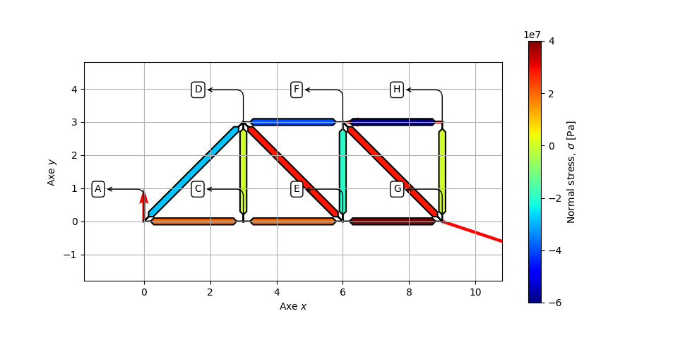

```python
E       = 210.e9   # Young Modulus [Pa]
rho     = 7800.    # Density       [kg/m**3]
A       = 5.e-2    # Cross section [m**2]
sigmay  = 400.e6   # Yield Stress  [Pa]

# Model definition
model = truss.core.Model() # Model definition

# NODES
nA = model.add_node((0.,0.), label = "A")
nC = model.add_node((3.,0.), label = "C")
nD = model.add_node((3.,3.), label = "D")
nE = model.add_node((6.,0.), label = "E")
nF = model.add_node((6.,3.), label = "F")
nG = model.add_node((9.,0.), label = "G")
nH = model.add_node((9.,3.), label = "H")

# BOUNDARY CONDITIONS
nA.block[1] = True
nG.block[0] = True
nH.block[0] = True

# BARS
AC = model.add_bar(nA, nC, modulus = E, density = rho, section = A, yield_stress = sigmay)
CD = model.add_bar(nC, nD, modulus = E, density = rho, section = A, yield_stress = sigmay)
AD = model.add_bar(nA, nD, modulus = E, density = rho, section = A, yield_stress = sigmay)
CE = model.add_bar(nC, nE, modulus = E, density = rho, section = A, yield_stress = sigmay)
DF = model.add_bar(nD, nF, modulus = E, density = rho, section = A, yield_stress = sigmay)
DE = model.add_bar(nD, nE, modulus = E, density = rho, section = A, yield_stress = sigmay)
EF = model.add_bar(nE, nF, modulus = E, density = rho, section = A, yield_stress = sigmay)
EG = model.add_bar(nE, nG, modulus = E, density = rho, section = A, yield_stress = sigmay)
FH = model.add_bar(nF, nH, modulus = E, density = rho, section = A, yield_stress = sigmay)
FG = model.add_bar(nF, nG, modulus = E, density = rho, section = A, yield_stress = sigmay)
GH = model.add_bar(nG, nH, modulus = E, density = rho, section = A, yield_stress = sigmay)

# STRUCTURAL LOADING
nG.force = np.array([0., -1.e6])


model.solve()



xlim, ylim = model.bbox(deformed = False)
fig = plt.figure()
ax = fig.add_subplot(1,1,1)
ax.set_aspect("equal")
#ax.axis("off")
model.draw(ax, deformed = False, field = "stress", label = True, force_scale = 1.e-6, forces = True)
plt.xlim(xlim)
plt.ylim(ylim)
plt.grid()
plt.xlabel("Axe $x$")
plt.ylabel("Axe $y$")
```

### Detailed results at the nodes

```python
model.data(at = "nodes")
```

|  | block bx | block by | coords x | coords y | disp ux | disp uy | force Fx | force Fy | label o |
| --- | --- | --- | --- | --- | --- | --- | --- | --- | --- |
| 0 | False | True | 0 | 0 | -0.00114286 | 0 | 0 | 1e+06 | A |
| 1 | False | False | 3 | 0 | -0.000857143 | -0.00337955 | 0 | 0 | C |
| 2 | False | False | 3 | 3 | 0.00142857 | -0.00337955 | 0 | 0 | D |
| 3 | False | False | 6 | 0 | -0.000571429 | -0.00618767 | 0 | 0 | E |
| 4 | False | False | 6 | 3 | 0.000857143 | -0.00647339 | 0 | 0 | F |
| 5 | True | False | 9 | 0 | 0 | -0.00813865 | 3e+06 | -1e+06 | G |
| 6 | True | False | 9 | 3 | 0 | -0.00813865 | -3e+06 | 0 | H |

### Detailed results on the bars

```python
model.data(at = "bars")
```

|  | conn c1 | conn c2 | direction dx | direction dy | geometry length | geometry volume | props density | props mass | props section | state elongation | state failure | state strain | state stress | state tension |
| --- | --- | --- | --- | --- | --- | --- | --- | --- | --- | --- | --- | --- | --- | --- |
| 0 | A | C | 1 | 0 | 3 | 0.15 | 7800 | 1170 | 0.05 | 0.000285714 | False | 9.52381e-05 | 2e+07 | 1e+06 |
| 1 | C | D | 0 | 1 | 3 | 0.15 | 7800 | 1170 | 0.05 | 0 | False | 0 | 0 | 0 |
| 2 | A | D | 0.707107 | 0.707107 | 4.24264 | 0.212132 | 7800 | 1654.63 | 0.05 | -0.000571429 | False | -0.000134687 | -2.82843e+07 | -1.41421e+06 |
| 3 | C | E | 1 | 0 | 3 | 0.15 | 7800 | 1170 | 0.05 | 0.000285714 | False | 9.52381e-05 | 2e+07 | 1e+06 |
| 4 | D | F | 1 | 0 | 3 | 0.15 | 7800 | 1170 | 0.05 | -0.000571429 | False | -0.000190476 | -4e+07 | -2e+06 |
| 5 | D | E | 0.707107 | -0.707107 | 4.24264 | 0.212132 | 7800 | 1654.63 | 0.05 | 0.000571429 | False | 0.000134687 | 2.82843e+07 | 1.41421e+06 |
| 6 | E | F | 0 | 1 | 3 | 0.15 | 7800 | 1170 | 0.05 | -0.000285714 | False | -9.52381e-05 | -2e+07 | -1e+06 |
| 7 | E | G | 1 | 0 | 3 | 0.15 | 7800 | 1170 | 0.05 | 0.000571429 | False | 0.000190476 | 4e+07 | 2e+06 |
| 8 | F | H | 1 | 0 | 3 | 0.15 | 7800 | 1170 | 0.05 | -0.000857143 | False | -0.000285714 | -6e+07 | -3e+06 |
| 9 | F | G | 0.707107 | -0.707107 | 4.24264 | 0.212132 | 7800 | 1654.63 | 0.05 | 0.000571429 | False | 0.000134687 | 2.82843e+07 | 1.41421e+06 |
| 10 | G | H | 0 | 1 | 3 | 0.15 | 7800 | 1170 | 0.05 | 0 | False | 0 | 0 | 0 |

### Dead (or structural) mass

```python
m0 = model.mass()
m0 * 1.e-3 # Mass in tons !
```

```
14.323889603929565
```

## Questions

**Question 1**: Verify that the yield stress is not exceeded anywhere, do you think this structure has an optimimum weight ? You can use the *state/failure* data available on the whole model.

```python
# Example:
model.data(at = "bars").state.failure.values

#...
```

```
array([False, False, False, False, False, False, False, False, False,
       False, False], dtype=object)
```

**Question 2**: Modify all the cross sections at the same time in order to minimize weight while keeping acceptable stress level.

**Question 3**: We want to modify the position along the $\vec y$ axis of the points $D$, $F$ and $H$ in order to minimize the vertical displacement of the node $G$ times the mass of the structure $\alpha$:

$$ \alpha = |u_y(G)| m $$

Where $u_y(G)$ is the displacement of the node $G$ along the $\vec y$ axis and $m$ the mass of the whole structure.

**Question 4**: Same question with displacements also along $\vec x$ of $C$, $D$, $E$ and $F$. Is it better ?

**Question 5**: You can now try to perform topological optimization by removing/merging well chosen beams and nodes. In order to make the structure even more efficient.

**Question 6**: You are now asked to optimize the cross section along with the position of $C$, $D$, $E$ and $F$ in order to reach the yield stress in each individual beam.